# Companies House - Logistic Regression

```python
import pandas as pd
from sklearn.model_selection import train_test_split
from sklearn.preprocessing import OneHotEncoder
from sklearn.compose import ColumnTransformer
from sklearn.pipeline import Pipeline
from sklearn.linear_model import LogisticRegression
from sklearn.metrics import (
    classification_report,
    roc_auc_score,
    RocCurveDisplay,
    ConfusionMatrixDisplay,
    PrecisionRecallDisplay
)
import matplotlib.pyplot as plt
import numpy as np


# ---------------------------------------------------------
# 1. Load the final modelling dataset
# ---------------------------------------------------------
# We saved the cleaned and prepared dataset earlier as a Parquet file.
# Here we load it into a DataFrame so we can use it for modelling.

data_path = r"C:\Users\AT355573\Documents\DS_Assignments\Companies House\data_processed\model_ready_data.parquet"
df = pd.read_parquet(data_path)

df
```

|  | company_category | company_age_when_acc_due | accounts_category | industry | psc_count | has_corporate_psc | has_foreign_psc | recent_psc_change | overdue |
| --- | --- | --- | --- | --- | --- | --- | --- | --- | --- |
| 0 | LTD | 10–20 | DORMANT | Public & Non‑Market | 2 | 0 | 1 | 0 | 0 |
| 1 | LTD | 5–10 | DORMANT | Information & Communication | 1 | 0 | 0 | 0 | 0 |
| 2 | LTD | 0–2 | OTHER | Health & Social Care | 1 | 0 | 0 | 1 | 0 |
| 3 | LTD | 2–5 | EXEMPT | Professional, Scientific & Tech | 1 | 0 | 1 | 0 | 0 |
| 4 | LTD | 5–10 | STANDARD ACTIVE | Information & Communication | 1 | 0 | 0 | 0 | 0 |
| ... | ... | ... | ... | ... | ... | ... | ... | ... | ... |
| 5506689 | LTD | 10–20 | EXEMPT | Admin & Support Services | 1 | 0 | 1 | 0 | 0 |
| 5506690 | LTD | 0–2 | OTHER | Real Estate | 1 | 1 | 1 | 1 | 0 |
| 5506691 | LTD | 5–10 | STANDARD ACTIVE | Accommodation & Food | 3 | 0 | 1 | 0 | 0 |
| 5506692 | LTD | 0–2 | OTHER | Other Services | 1 | 0 | 1 | 0 | 0 |
| 5506693 | LTD | 20+ | DORMANT | Public & Non‑Market | 5 | 1 | 1 | 0 | 0 |

5506694 rows × 9 columns

```python
# ---------------------------------------------------------
# 2. Define features (X) and target (y)
# ---------------------------------------------------------
# 'overdue' is the variable we want to predict (0 = on time, 1 = late).
# X contains all other columns that will be used as predictors.

target = "overdue"
X = df.drop(columns=[target])
y = df[target]

# Identify which columns are categorical and which are numeric.
categorical_cols = X.select_dtypes(include="category").columns.tolist()
numeric_cols = X.select_dtypes(include=["int64", "int8", "float64"]).columns.tolist()
```

```python
# ---------------------------------------------------------
# 3. Preprocessing: One-hot encode categorical variables
# ---------------------------------------------------------
# Logistic regression cannot work directly with text categories.
# OneHotEncoder turns each category into a 0/1 column.
# drop="first" avoids multicollinearity.

preprocessor = ColumnTransformer(
    transformers=[
        ("cat", OneHotEncoder(drop="first"), categorical_cols),
        ("num", "passthrough", numeric_cols)
    ]
)
```

```python
# ---------------------------------------------------------
# 4. Build the logistic regression pipeline
# ---------------------------------------------------------
# A pipeline keeps preprocessing and modelling together.
# This ensures the same steps are applied consistently during training and testing.

model = Pipeline(
    steps=[
        ("preprocess", preprocessor),
        ("logreg", LogisticRegression(max_iter=1000))
    ]
)
```

```python
# ---------------------------------------------------------
# 5. Train/test split
# ---------------------------------------------------------
# We split the data so we can test the model on unseen data.
# stratify=y keeps the proportion of overdue companies the same in both sets.

X_train, X_test, y_train, y_test = train_test_split(
    X, y, test_size=0.2, stratify=y, random_state=42
)

print("Class balance:", y_train.value_counts())
```

```
Class balance: overdue
0    4043709
1     361646
Name: count, dtype: int64
```

This demonstrates a highly imbalanced dataset, with only 8.2% of companies filing late. To address this imbalance, SMOTE will be applied, synthesising new minority-class examples so that the number of examples matches the number of examples of the majority class. This will ensure that the logisitc regression model receives equal representation for both classes during training. SMOTE is very resource intensive when datasets have a lot of categories and a lot of rows, like Companies House data which is millions of rows.

```python
# ---------------------------------------------------------
# 5a. Take a stratified sample of the training data
# ---------------------------------------------------------
# This reduces the dataset size so SMOTE + logistic regression run much faster.
# 20% is a good balance between speed and performance.

X_train_sampled, _, y_train_sampled, _ = train_test_split(
    X_train, y_train,
    train_size=0.2,
    stratify=y_train,
    random_state=42
)

print("Training size BEFORE sampling:", len(y_train))
print("Training size AFTER sampling:", len(y_train_sampled))
```

```
Training size BEFORE sampling: 4405355
Training size AFTER sampling: 881071
```

```python
# ---------------------------------------------------------
# 5b. Show class balance BEFORE and AFTER SMOTE (conceptual)
# ---------------------------------------------------------
print("\nClass balance BEFORE SMOTE:")
print(y_train_sampled.value_counts())

majority = y_train_sampled.value_counts()[0]

print("\nClass balance AFTER SMOTE (conceptual):")
print(pd.Series([0]*majority + [1]*majority).value_counts())
```

```
Class balance BEFORE SMOTE:
overdue
0    808742
1     72329
Name: count, dtype: int64

Class balance AFTER SMOTE (conceptual):
0    808742
1    808742
Name: count, dtype: int64
```

```python
# ---------------------------------------------------------
# 6. Build the modelling pipeline WITH SMOTE inside it
# ---------------------------------------------------------
from imblearn.pipeline import Pipeline
from imblearn.over_sampling import SMOTE

model = Pipeline(
    steps=[
        ("preprocess", preprocessor),
        ("smote", SMOTE(random_state=42)),
        ("logreg", LogisticRegression(max_iter=1000))
    ]
)
```

```python
# ---------------------------------------------------------
# 6. Fit the model
# ---------------------------------------------------------
# The model learns the relationship between the features and the target.

model.fit(X_train_sampled, y_train_sampled)
```

```
Pipeline(steps=[('preprocess',
                 ColumnTransformer(transformers=[('cat',
                                                  OneHotEncoder(drop='first'),
                                                  ['company_category',
                                                   'company_age_when_acc_due',
                                                   'accounts_category',
                                                   'industry']),
                                                 ('num', 'passthrough',
                                                  ['psc_count',
                                                   'has_corporate_psc',
                                                   'has_foreign_psc',
                                                   'recent_psc_change'])])),
                ('smote', SMOTE(random_state=42)),
                ('logreg', LogisticRegression(max_iter=1000))])
```

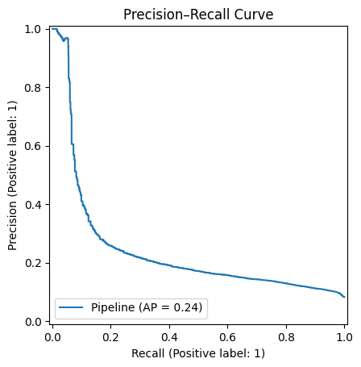

```python
# ---------------------------------------------------------
# GRAPH 3: Precision–Recall Curve
# ---------------------------------------------------------
# Useful when the target class is imbalanced.

PrecisionRecallDisplay.from_estimator(model, X_test, y_test)
plt.title("Precision–Recall Curve")
plt.show()
```

```python
# ---------------------------------------------------------
# 6a. Threshold tuning: change precision and recall
# ---------------------------------------------------------

# 1. Get predicted probabilities for class 1 (late filers)
y_scores = model.predict_proba(X_test)[:, 1]

# 2. Choose a threshold (example: 0.7)
threshold = 0.7

# 3. Evaluate at threshold 0.5
y_pred_default = (y_scores >= 0.5).astype(int)
print(classification_report(y_test, y_pred_default))
```

```
              precision    recall  f1-score   support

           0       0.96      0.58      0.73   1010928
           1       0.14      0.75      0.23     90411

    accuracy                           0.60   1101339
   macro avg       0.55      0.66      0.48   1101339
weighted avg       0.89      0.60      0.69   1101339
```

```python
from sklearn.metrics import precision_score, recall_score, f1_score, confusion_matrix
import pandas as pd

thresholds = [0.60, 0.65, 0.70, 0.75]
results = []

for t in thresholds:
    y_pred_t = (y_scores >= t).astype(int)

    prec = precision_score(y_test, y_pred_t)
    rec = recall_score(y_test, y_pred_t)
    f1 = f1_score(y_test, y_pred_t)
    tn, fp, fn, tp = confusion_matrix(y_test, y_pred_t).ravel()

    results.append({
        "threshold": t,
        "precision": prec,
        "recall": rec,
        "f1": f1,
        "TP": tp,
        "FP": fp,
        "FN": fn,
        "TN": tn
    })

threshold_df = pd.DataFrame(results)
threshold_df
```

|  | threshold | precision | recall | f1 | TP | FP | FN | TN |
| --- | --- | --- | --- | --- | --- | --- | --- | --- |
| 0 | 0.60 | 0.170397 | 0.506587 | 0.255016 | 45801 | 222989 | 44610 | 787939 |
| 1 | 0.65 | 0.210192 | 0.324927 | 0.255259 | 29377 | 110386 | 61034 | 900542 |
| 2 | 0.70 | 0.268047 | 0.184491 | 0.218555 | 16680 | 45548 | 73731 | 965380 |
| 3 | 0.75 | 0.438956 | 0.096913 | 0.158772 | 8762 | 11199 | 81649 | 999729 |

Threshold tuning was performed to evaluate the trade‑off between precision and recall. Lower thresholds (e.g., 0.60) produced high recall but very low precision, resulting in a large number of false positives. Higher thresholds (e.g., 0.75) achieved much higher precision but at the cost of missing the majority of late filers. A threshold of 0.70 provided the most balanced performance, improving precision to 0.27 while maintaining a usable recall of 0.18 and substantially reducing false positives. This threshold aligns with the elbow of the precision–recall curve and represents the most appropriate operating point for this model.

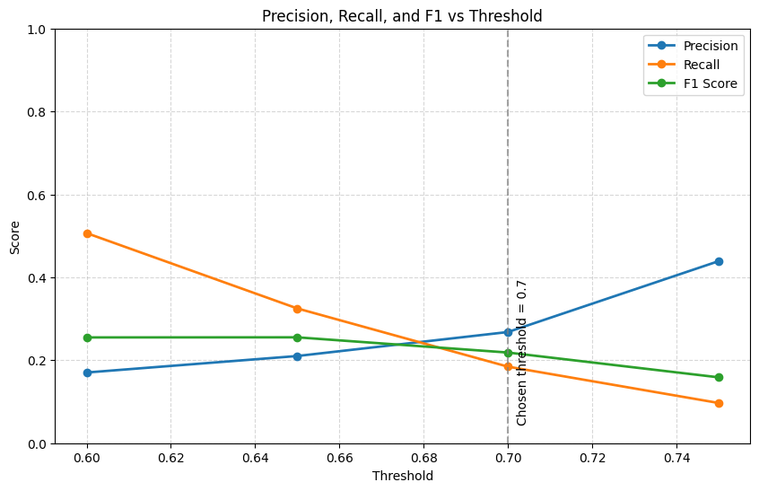

```python
import matplotlib.pyplot as plt

thresholds = threshold_df["threshold"]
precisions = threshold_df["precision"]
recalls = threshold_df["recall"]
f1s = threshold_df["f1"]

plt.figure(figsize=(10, 6))

plt.plot(thresholds, precisions, marker='o', label='Precision', linewidth=2)
plt.plot(thresholds, recalls, marker='o', label='Recall', linewidth=2)
plt.plot(thresholds, f1s, marker='o', label='F1 Score', linewidth=2)

# Optional: highlight your chosen threshold (e.g., 0.70)
chosen = 0.70
plt.axvline(chosen, color='grey', linestyle='--', alpha=0.7)
plt.text(chosen + 0.002, 0.05, f"Chosen threshold = {chosen}", rotation=90)

plt.title("Precision, Recall, and F1 vs Threshold")
plt.xlabel("Threshold")
plt.ylabel("Score")
plt.ylim(0, 1)
plt.grid(True, linestyle='--', alpha=0.5)
plt.legend()

plt.show()
```

A threshold of 0.70 was selected as the final operating point. This threshold provided the best balance between precision and recall, improving precision to 0.27 while maintaining a usable recall of 0.18. It also substantially reduced false positives compared to lower thresholds and aligned with the elbow of the precision–recall curve, making it the most appropriate choice for this imbalanced classification problem